# CMEMS WORKSHOP

How to access and handle data from the Copernicus Marine Service

Carlo Zampieri

## Outline

- Copernicus and its services
- CMEMS DATA
- Data exploration
- Downloading options
- Data handling
- NECCTON

# Copernicus and its services

## Copernicus

[**Copernicus**](https://eu-space.europa.eu/programmes/earth-observation-copernicus) is the Earth observation component of the European Union’s Space programme, looking at our planet and its environment to benefit all European citizens. It offers information services that draw from **satellite Earth Observation and in-situ (non-space) data.**

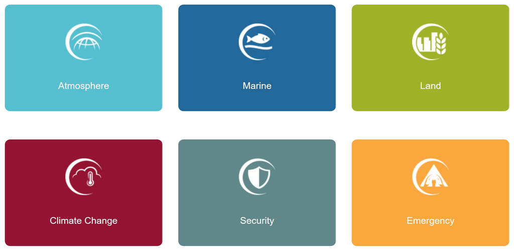

## The CMEMS

The [Copernicus Marine Environment Monitoring Service](https://marine.copernicus.eu/), or simply Copernicus Marine Service, provide free and open marine data and services to support marine policy implementation, Blue growth and scientific innovation.

- [Data](https://marine.copernicus.eu/access-data/) (explore, visualise, download)
- [Support & Expertise](https://marine.copernicus.eu/user-corner/) (e-learning, FAQ, help)
- [Services](https://marine.copernicus.eu/services/) (events, workshops, digital tools)

# CMEMS DATA

## Data families

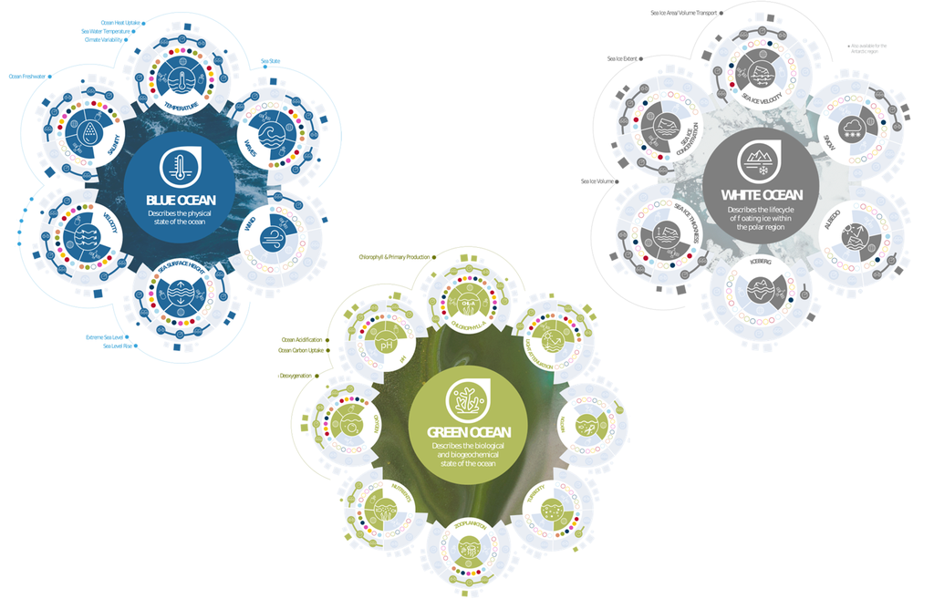

## Data sources

- Satellite and in-situ observations
- Numerical models
- Indicators

[figure not shown]

## Observations - processing levels<sup>1</sup>

| Level 0 (L0) | Unprocessed instrument data |
| --- | --- |
| Level 1 (L1) | Data processed to sensor unit |
| Level 2 (L2) | Derived geophysical variables |
| Level 3 (L3) | Georeferenced data |
| Level 4 (L4) | Greatest amount of processing applied, including modelled output and measurements from several satellites and several days. All input data are validated. |

[^1]: See the example [here](https://help.marine.copernicus.eu/en/articles/5046705-which-levels-are-used-for-data-processing) or know more about processing levels [here](https://www.earthdata.nasa.gov/learn/earth-observation-data-basics/data-processing-levels)

## Modelling types<sup>1</sup>

- Forecast (assessment of the future)
- Hindcast (assessment of the past)
  - simulation (without data assimilation)
  - analysis (with data assimilation)
- Reanalysis (assessment over a long period of time corrected by observations)
[^2]: Learn more [here](https://help.marine.copernicus.eu/en/articles/4575382-what-are-the-different-data-types-provided-by-copernicus-marine)

# Data exploration

## Copernicus Marine Data Store

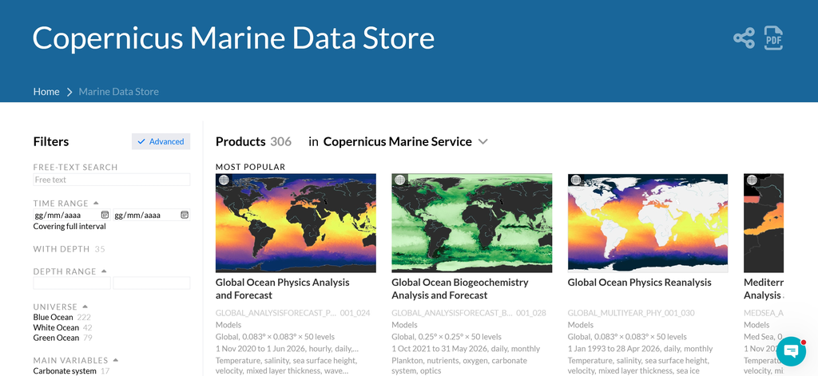

## Copernicus visualisation tools

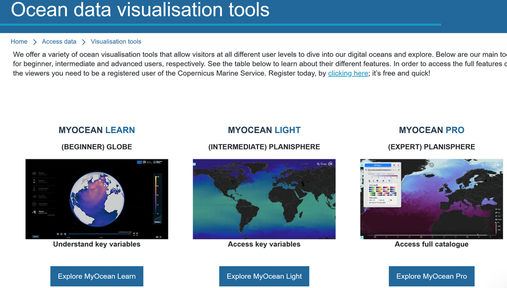

# Downloading options

## Download from MyOcean Pro

[figure not shown]

## Download from the Copernicus Marine Data Store

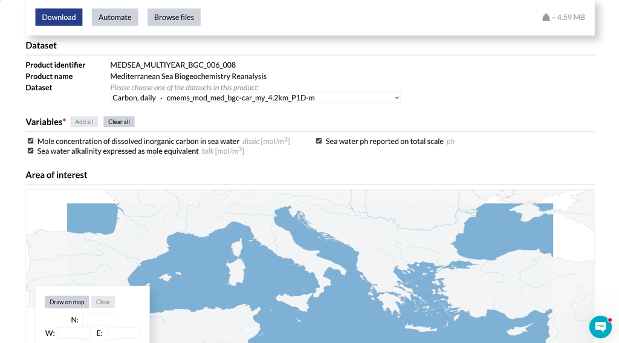

## Download with an API

The [Copernicus Marine Toolbox API](https://help.marine.copernicus.eu/en/articles/7949409-copernicus-marine-toolbox-introduction) is a Python module which allows to explore and download all the products provided in the CMEMS catalogue without any limit.

[figure not shown]

```python
import copernicusmarine
copernicusmarine.login()
copernicusmarine.describe()
copernicusmarine.subset()
```

A brief tutorial on the toolbox is available with the workshop documentation.

# Data handling

[figure not shown]

# NECCTON

[NECCTON](https://neccton.eu/) is a new service of the CMEMS that collects products of fisheries, pollution and benthic habitats, with the aim of informing ocean policymakers, managers and publics about biodiversity conservation and fisheries management.

[figure not shown]